# Logistic regression

## Reading the joined data from the local folder

```r
# reading the data from a local folder

library(readr)
alc <- read.csv("data/joined_alc_data.csv")
```

## Exploration of the data

Original data source: https://www.archive.ics.uci.edu/dataset/320/student+performance

The data consist of information on secondary education student performance in Portugal. The data is joined from two data sets

```r
# Exploration of the data variables

str(alc)
```

```
## 'data.frame':    370 obs. of  35 variables:
##  $ school    : chr  "GP" "GP" "GP" "GP" ...
##  $ sex       : chr  "F" "F" "F" "F" ...
##  $ age       : int  18 17 15 15 16 16 16 17 15 15 ...
##  $ address   : chr  "U" "U" "U" "U" ...
##  $ famsize   : chr  "GT3" "GT3" "LE3" "GT3" ...
##  $ Pstatus   : chr  "A" "T" "T" "T" ...
##  $ Medu      : int  4 1 1 4 3 4 2 4 3 3 ...
##  $ Fedu      : int  4 1 1 2 3 3 2 4 2 4 ...
##  $ Mjob      : chr  "at_home" "at_home" "at_home" "health" ...
##  $ Fjob      : chr  "teacher" "other" "other" "services" ...
##  $ reason    : chr  "course" "course" "other" "home" ...
##  $ guardian  : chr  "mother" "father" "mother" "mother" ...
##  $ traveltime: int  2 1 1 1 1 1 1 2 1 1 ...
##  $ studytime : int  2 2 2 3 2 2 2 2 2 2 ...
```

[output cut: 21 more lines]

```r
colnames(alc)
```

```
##  [1] "school"     "sex"        "age"        "address"    "famsize"
##  [6] "Pstatus"    "Medu"       "Fedu"       "Mjob"       "Fjob"
## [11] "reason"     "guardian"   "traveltime" "studytime"  "schoolsup"
## [16] "famsup"     "activities" "nursery"    "higher"     "internet"
## [21] "romantic"   "famrel"     "freetime"   "goout"      "Dalc"
## [26] "Walc"       "health"     "failures"   "paid"       "absences"
## [31] "G1"         "G2"         "G3"         "alc_use"    "high_use"
```

- The data set has 370 observations and 35 variables.
  - There are character, intgrer and logical variables in the data
  - The variables give information on, e.g., students background, school performance in maths and Portuguese (test scores ‘G1’, ‘G2’, and final grade ‘G3’) and alcohol consumption
- The students are between 15-22 years of age.

The dependent binary variable ‘high_use’ is when the mean of ‘Dalc’ and ‘Walc’ > 2 * ‘Dalc’ - workday alcohol consumption numeric: from 1 - very low to 5 - very high) * ‘Walc’ - weekend alcohol consumption (numeric: from 1 - very low to 5 - very high)

In this analysis we will use logistic regression to test the relationship of four chosen background variables with the binary dependent variable ‘high_use’.

## Choosing the variables

- The variables:
  1. ‘school’ student’s school (binary: ‘GP’ - Gabriel Pereira or ‘MS’ - Mousinho da Silveira)
  2. ‘famrel’ quality of family relationships (numeric: from 1 - very bad to 5 - excellent)
  - actually an ordinal variable, categories with a clear order
  3. ‘studytime’ - weekly study time (numeric: 1 - <2 hours, 2 - 2 to 5 hours, 3 - 5 to 10 hours, or 4 - >10 hours)
  - also an ordinal variable
  4. ‘G3’ final grade (numeric: from 0 to 20, output target)

## Hypothesis:

The hypothesis for the variables:

- ‘school’ no effect, similar distributions.
  - The effect of school could still be there and affect the model so should be ruled out.
- ‘famrel’ family relationship negatively correlated with high alcohol use
  - better family relationship -> more time spent with family -> less alcohol consumption?
- ‘studytime’ could negatively correlate with high alcohol use - less time for drinking…
- ‘G3’ better final score could be negatively correlated with high use

## Exploration of the variable distributions

The distribution between the high and low alcohol use students:

```r
# Distribution of 'high_use' in the data set:
table(alc$high_use)
```

```
##
## FALSE  TRUE
##   259   111
```

There are over twice as many “low alcohol use” students than “high use” students in the data set.

## The distributions of the variables:

First, the variables ‘famrel’ and ‘studytime’ need to be changed to be categorical.

- (I think the variables should be ordinal so I used “ordered” function first, but that gave me some wonky results in the model that did not make sense to me… “factor” function seems to work better)
- I also added labels, the labels 2-4 in ‘famrel’ are made up as I did not find the exact wording…

```r
# Changing 'famrel' into factors and adding labels
alc$famrel <- factor(alc$famrel, labels = c(" very bad", " bad", " ok", " good", " excellent"))

levels(alc$famrel)
```

```
## [1] " very bad"  " bad"       " ok"        " good"      " excellent"
```

```r
# Changing 'studytime' into factors and adding labels
alc$studytime <- factor(alc$studytime, labels = c(" <2 hours", " 2 to 5 hours", " 5 to 10 hours", " >10 hours"))
```

Then we can see the overview of the chosen variables:

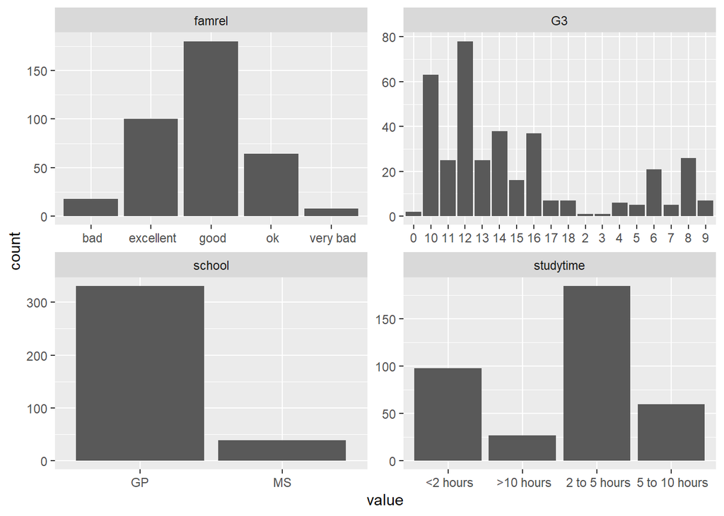

```r
# access the tidyverse libraries tidyr, dplyr, ggplot2
library(tidyr); library(dplyr); library(ggplot2)
# selecting the variables of interest
filtered_alc <- alc %>% select(school, famrel, studytime, G3)

# a bar plot of the variables
gather(filtered_alc) %>% ggplot(aes(value)) + facet_wrap("key", scales = "free") + geom_bar()
```

```r
# summaries of the variables
summary(filtered_alc)
```

```
##     school                 famrel             studytime         G3
##  Length:370          very bad :  8    <2 hours     : 98   Min.   : 0.00
##  Class :character    bad      : 18    2 to 5 hours :185   1st Qu.:10.00
##  Mode  :character    ok       : 64    5 to 10 hours: 60   Median :12.00
##                      good     :180    >10 hours    : 27   Mean   :11.52
##                      excellent:100                        3rd Qu.:14.00
##                                                           Max.   :18.00
```

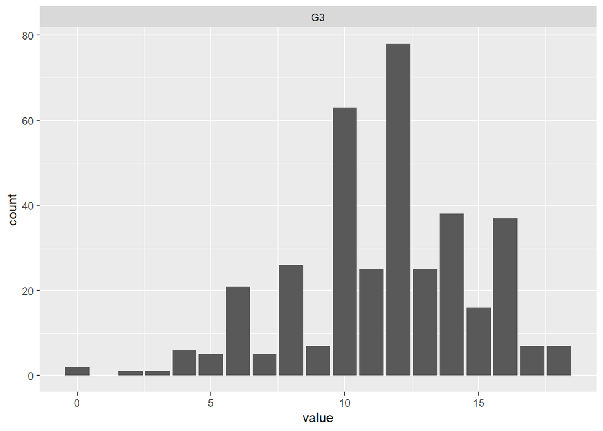

```r
# G3 looks very odd, lets make a separate plot for it...
G3_test <- alc %>% select(G3)

gather(G3_test) %>% ggplot(aes(value)) + facet_wrap("key", scales = "free") + geom_bar()
```

```r
# now it looks ok, go figure..
```

The variables on the plots are in a weird order and I cant fix that… Maybe it is the gather function

Next, the distribution of each of the variables in relation to alcohol use:

### School and alcohol

- Barplots and crosstables to see whether the schools have different amounts of ‘high_use’ students:

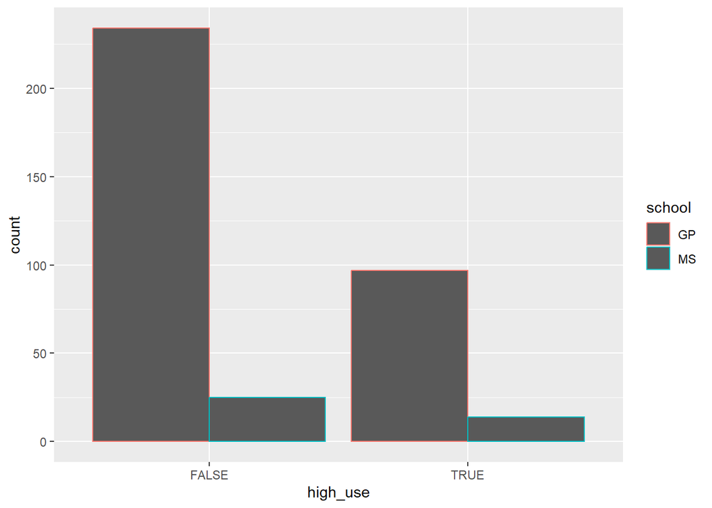

```r
# initialize a plot of high_use
g1 <- ggplot(data = alc, aes(x = high_use, col = school))

# drawing the bar plot
g1 + geom_bar(position = "dodge")
```

```r
# looking at a crosstable to see exact numbers:
school_tab <- table(high_use = alc$high_use, alc$school)

# a crostable using percentages:
alc_with_percentages <- prop.table(school_tab, 2) * 100

table(high_use = alc$high_use, alc$school)
```

```
##
## high_use  GP  MS
##    FALSE 234  25
##    TRUE   97  14
```

```r
alc_with_percentages
```

```
##
## high_use       GP       MS
##    FALSE 70.69486 64.10256
##    TRUE  29.30514 35.89744
```

GP (Gabriel Pereira) is a larger school (or had more respondents or participants in the survey) than MS (Mousinho da Silveira). MS had higher proportion of ‘high_use’, but the sample sizes are very different.

### Family relations and high alcohol use

Bar plots for values and then percentages:

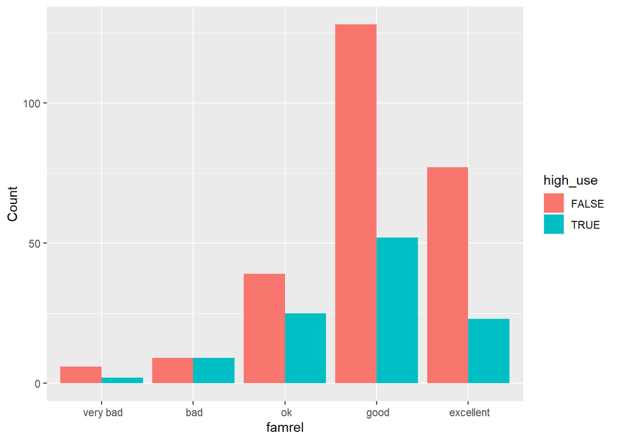

```r
# Create the bar plot with values
ggplot(alc, aes(x = famrel, fill = as.factor(high_use))) +
  geom_bar(position = "dodge") +
  labs(x = "famrel", y = "Count", fill = "high_use")
```

```r
# Calculate the percentages and counts for each category
famrel_summary <- alc %>%
  group_by(famrel, high_use) %>%
  summarise(count = n()) %>%
  mutate(perc = count / sum(count))
```

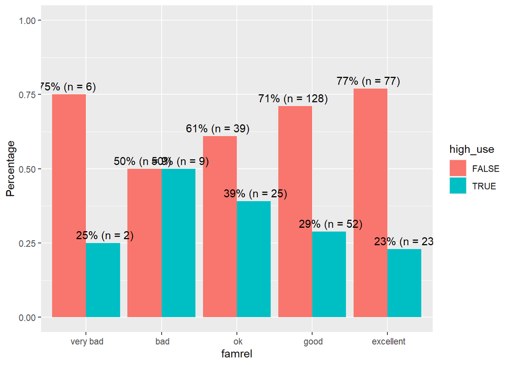

```r
# Create the bar plot with percentages and n
ggplot(famrel_summary, aes(x = famrel, y = perc, fill = as.factor(high_use))) +
  geom_bar(stat = "identity", position = "dodge") +
  geom_text(aes(label = paste0(round(perc*100), "% (n = ", count, ")")),
            position = position_dodge(width = 1), vjust = -0.5) +
  labs(x = "famrel", y = "Percentage", fill = "high_use") +
  ylim(0, 1)
```

It would appear that proportion of high use decreases when the reported family relations improve. There does seem to be lower proportion of high alcohol use in students who reported extremely poor family relationships. However, there are very few students in the very poor ‘famrel’ category.

The same data in a table form:

```r
# table with high alcohol use and family relations

famrel_tab <- table(high_use = alc$high_use, alc$famrel)

# adding percentages:

famreltab_with_percentages <- prop.table(famrel_tab, 2) * 100

table(high_use = alc$high_use, alc$famrel)
```

```
##
## high_use  very bad  bad  ok  good  excellent
##    FALSE         6    9  39   128         77
##    TRUE          2    9  25    52         23
```

```r
famreltab_with_percentages
```

```
##
## high_use  very bad      bad       ok     good  excellent
##    FALSE  75.00000 50.00000 60.93750 71.11111   77.00000
##    TRUE   25.00000 50.00000 39.06250 28.88889   23.00000
```

### Study time and alcohol use

Bar plots for values and then percentages:

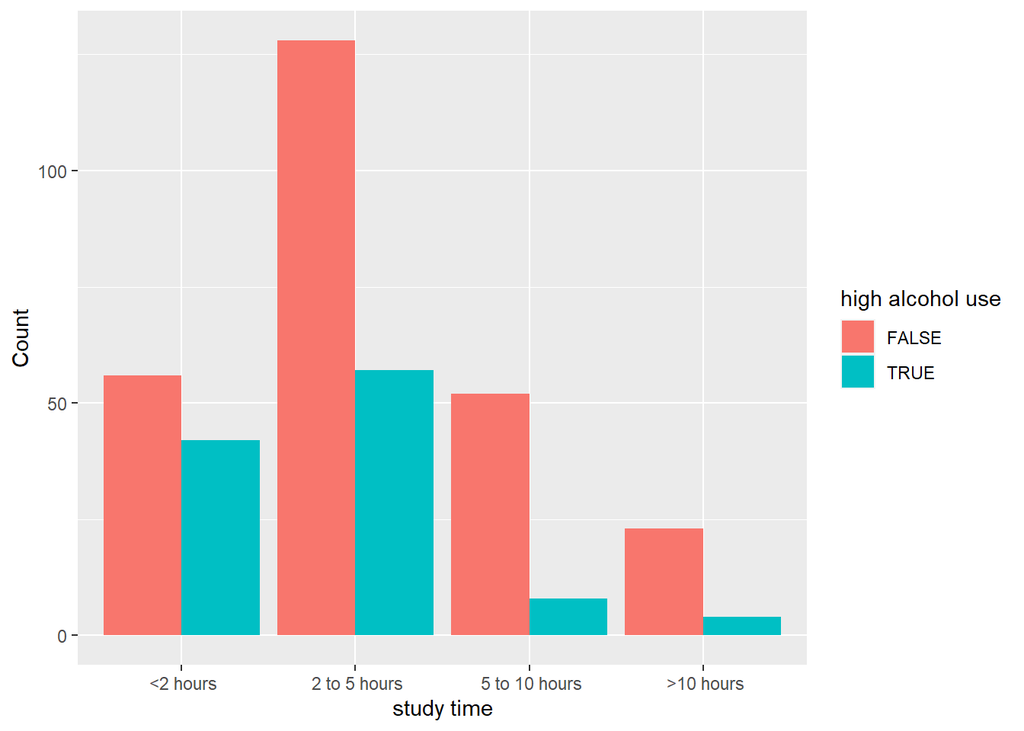

```r
# Create the bar plot with values
ggplot(alc, aes(x = studytime, fill = as.factor(high_use))) +
  geom_bar(position = "dodge") +
  labs(x = "study time", y = "Count", fill = "high alcohol use")
```

```r
# Calculate the percentages and counts for each category
studytime_summary <- alc %>%
  group_by(studytime, high_use) %>%
  summarise(count = n()) %>%
  mutate(perc = count / sum(count))
```

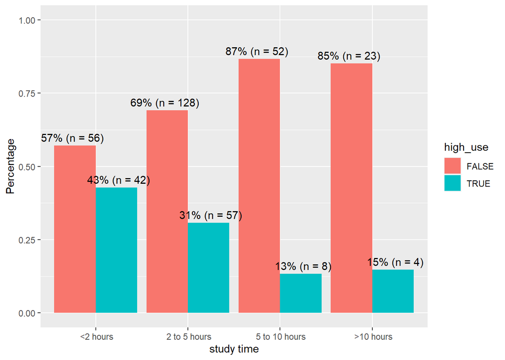

```r
# Create the bar plot with percentages and n
ggplot(studytime_summary, aes(x = studytime, y = perc, fill = as.factor(high_use))) +
  geom_bar(stat = "identity", position = "dodge") +
  geom_text(aes(label = paste0(round(perc*100), "% (n = ", count, ")")),
            position = position_dodge(width = 1), vjust = -0.5) +
  labs(x = "study time", y = "Percentage", fill = "high_use") +
  ylim(0, 1)
```

Based on the bar plot, it does seem that ‘studytime’ is indeed negatively correlated with ‘high_use’

The same data in a table form:

```r
# table with high alcohol use and study time

studytime_tab <- table(high_use = alc$high_use, alc$studytime)

# adding percentages:

studytimetab_with_percentages <- prop.table(studytime_tab, 2) * 100

table(high_use = alc$high_use, alc$studytime)
```

```
##
## high_use  <2 hours  2 to 5 hours  5 to 10 hours  >10 hours
##    FALSE        56           128             52         23
##    TRUE         42            57              8          4
```

```r
studytimetab_with_percentages
```

```
##
## high_use  <2 hours  2 to 5 hours  5 to 10 hours  >10 hours
##    FALSE  57.14286      69.18919       86.66667   85.18519
##    TRUE   42.85714      30.81081       13.33333   14.81481
```

### Final test result (G3) and high alcohol use

We create a boxplot for the to illustrate the potential relationship between final test results (numeric variable) and high alcohol use:

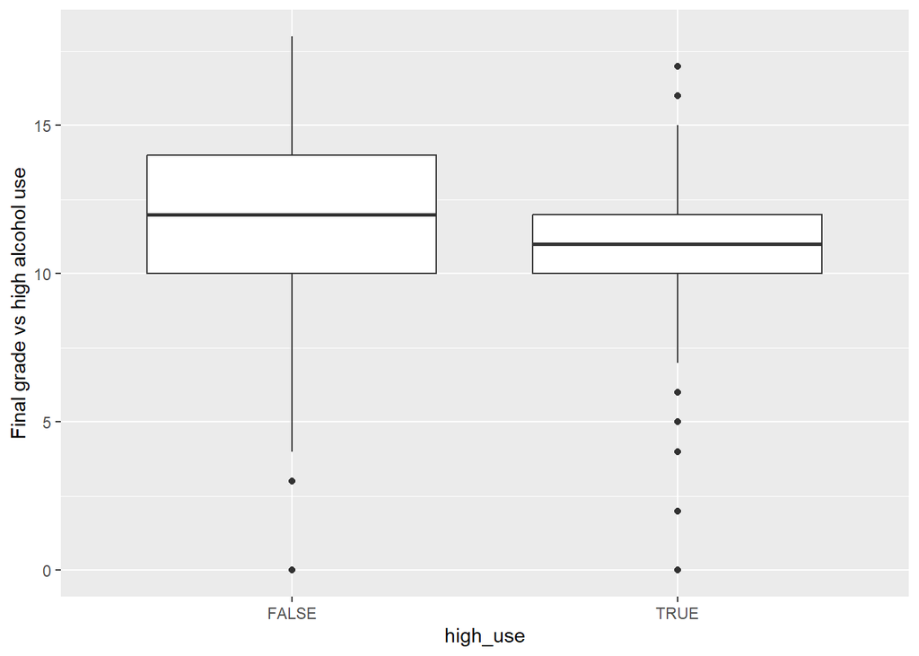

```r
# initialize a plot of high_use and G3
g1 <- ggplot(alc, aes(x = high_use, y = G3))

# define the plot as a boxplot and draw it
g1 + geom_boxplot() + ylab("Final grade vs high alcohol use")
```

There does not seem to be much of an effect of high alcohol use on final grade (‘G3’).

## Statistical analysis

Creating the model with the chosen variables:

- ‘school’
- ‘famrel’
- ‘studytime’
- ‘G3’

Creating and printing the model:

```r
# find the model with glm()
m <- glm(high_use ~ school + famrel + studytime + G3, data = alc, family = "binomial")

# print out a summary of the model
summary(m)
```

```
##
## Call:
## glm(formula = high_use ~ school + famrel + studytime + G3, family = "binomial",
##     data = alc)
##
## Coefficients:
##                         Estimate Std. Error z value Pr(>|z|)
## (Intercept)              0.09027    0.96477   0.094  0.92545
## schoolMS                 0.09774    0.37929   0.258  0.79665
## famrel bad               0.96006    0.96890   0.991  0.32175
## famrel ok                0.58415    0.88300   0.662  0.50826
## famrel good              0.21688    0.85937   0.252  0.80075
## famrel excellent        -0.12296    0.87775  -0.140  0.88859
## studytime 2 to 5 hours  -0.45606    0.26678  -1.709  0.08736 .
## studytime 5 to 10 hours -1.43196    0.43962  -3.257  0.00113 **
## studytime >10 hours     -1.36219    0.59211  -2.301  0.02142 *
## G3                      -0.06041    0.03673  -1.645  0.10003
## ---
## Signif. codes:  0 '***' 0.001 '**' 0.01 '*' 0.05 '.' 0.1 ' ' 1
##
## (Dispersion parameter for binomial family taken to be 1)
##
##     Null deviance: 452.04  on 369  degrees of freedom
## Residual deviance: 422.56  on 360  degrees of freedom
## AIC: 442.56
##
## Number of Fisher Scoring iterations: 4
```

```r
# print out the coefficients of the model
coef(m)
```

```
##             (Intercept)                schoolMS              famrel bad
##              0.09027131              0.09773687              0.96006061
##               famrel ok             famrel good        famrel excellent
##              0.58414986              0.21688453             -0.12295941
##  studytime 2 to 5 hours studytime 5 to 10 hours     studytime >10 hours
##             -0.45606075             -1.43196021             -1.36218503
##                      G3
##             -0.06041110
```

Based on the model:

The calculation of the odds ratios:

```r
# compute odds ratios (OR)
OR <- coef(m) %>% exp

# compute confidence intervals (CI)
CI <- confint(m) %>% exp
# print out the odds ratios with their confidence intervals
cbind(OR, CI)
```

```
##                                OR      2.5 %     97.5 %
## (Intercept)             1.0944712 0.13080942  6.6751067
## schoolMS                1.1026726 0.51291952  2.2911229
## famrel bad              2.6118548 0.42863806 22.1092159
## famrel ok               1.7934656 0.35434586 13.3845382
## famrel good             1.2422007 0.25855541  8.9733484
## famrel excellent        0.8842996 0.17649602  6.5482380
## studytime 2 to 5 hours  0.6337753 0.37558562  1.0709740
## studytime 5 to 10 hours 0.2388403 0.09508293  0.5427036
## studytime >10 hours     0.2561006 0.06964312  0.7490803
## G3                      0.9413775 0.87536281  1.0113400
```

- With ‘famrel’ the lack of significance could be because the reference category ‘famrel very bad’ had only a few students in it and is not reliable…
- The only confidence intervals that do not include 1 are ‘studytime 5 to 10 hours’ and ‘studytime >10 hours’.
  - ‘studytime’ is significantly correlated with ‘high_use’, this is consistent with the significance values in the previous table
- Based on the odds ratios, for example, for students in ‘studytime > 10 hours’ category have 0.26 times lower odds to be in the high_use category as those with ‘studytime < 2 hours’

## The predictive power of the model

```r
# fit the model
m_studytime <- glm(high_use ~ studytime, data = alc, family = "binomial")

# predict() the probability of high_use
probabilities <- predict(m, type = "response")

library(dplyr)
# add the predicted probabilities to 'alc'
alc <- mutate(alc, probability = probabilities)

# use the probabilities to make a prediction of high_use
alc <- mutate(alc, prediction = c(probability > 0.5))

# see the last ten original classes, predicted probabilities, and class predictions
select(alc, studytime, high_use, probability, prediction) %>% tail(10)
```

```
##          studytime high_use probability prediction
## 361   2 to 5 hours    FALSE   0.3022698      FALSE
## 362       <2 hours    FALSE   0.5998626       TRUE
## 363       <2 hours     TRUE   0.4860603      FALSE
## 364  5 to 10 hours    FALSE   0.1098920      FALSE
## 365       <2 hours    FALSE   0.4804110      FALSE
## 366  5 to 10 hours    FALSE   0.1585620      FALSE
## 367   2 to 5 hours    FALSE   0.3151608      FALSE
## 368   2 to 5 hours    FALSE   0.3752646      FALSE
## 369       <2 hours     TRUE   0.5896998       TRUE
## 370       <2 hours     TRUE   0.4503595      FALSE
```

```r
# tabulate the target variable versus the predictions
table(high_use = alc$high_use, alc$prediction)
```

```
##
## high_use FALSE TRUE
##    FALSE   246   13
##    TRUE    100   11
```

Based on the matrix the model provided:

- 246 true negatives
- 11 true positives
- 13 false positives
- 100 false negatives

The model does not seem to predict very well. It highly underestimates the high alcohol use, giving high number of false negatives.

The guessing (hypothesises) were in line with the distributions of the variables in high and low use categories. However, the model does not indicate that ‘famrel’ is significantly correlated with high alcohol use. ‘school’ and ‘G3’ did not indicate a large effect at any point of data exploration.